# 9 Gene Enrichment Analysis

Published

November 5, 2025

To identify biological pathways and processes affected by Cre-mediated ApoE4→ApoE2 conversion in liver tissue, we performed complementary enrichment analyses using the high-confidence differentially expressed genes from Method 1 (combined batches, no batch adjustment).

## 9.1 Liver

### 9.1.1 Over-Representation Analysis (ORA)

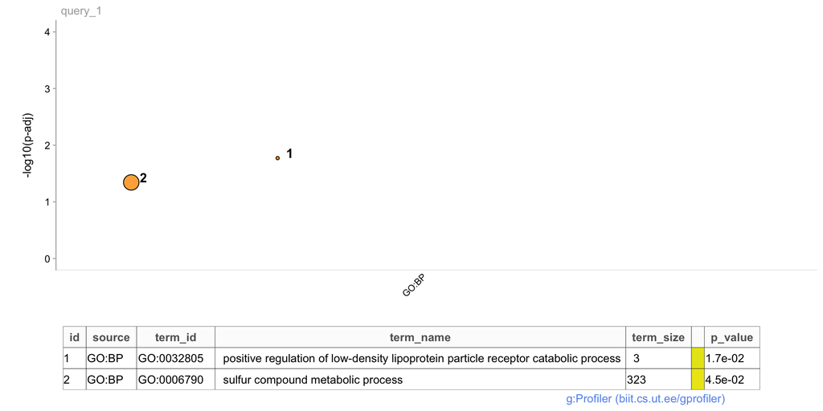

Over-representation analysis using `g:Profiler2` identified two significantly enriched Gene Ontology Biological Process terms among the 63 liver DEGs (Method 1, FDR < 0.01, |log₂FC| > 1). The most significant enrichment was for positive regulation of low-density lipoprotein particle receptor catabolic process (GO:0032805, p = 1.7×10⁻², 3 genes), directly implicating lipoprotein receptor regulation in the transcriptional response.

The second enriched term was sulfur compound metabolic process (GO:0006790, p = 4.5×10⁻², 323 genes), a broad metabolic category that may reflect secondary metabolic remodeling following altered lipid handling. While this enrichment is less specific, it suggests that ApoE isoform conversion triggers broader metabolic adaptations beyond lipid metabolism alone.

The limited number of significantly enriched terms in ORA likely reflects the modest size of the high-confidence DEG list (63 genes after stringent filtering), which reduces statistical power to detect over-representation in narrowly defined functional categories. This motivated the use of Gene Set Enrichment Analysis as a complementary approach that leverages information from all genes rather than only those passing significance thresholds.

### 9.1.2 Gene Set Enrichment Analysis (GSEA)

| pathway | NES | padj | size |
| --- | --- | --- | --- |
| GOBP_PROTON_MOTIVE_FORCE_DRIVEN_ATP_SYNTHESIS | 2.136 | 0.004 | 70 |
| GOBP_NADH_DEHYDROGENASE_COMPLEX_ASSEMBLY | 2.111 | 0.004 | 62 |
| GOBP_MITOCHONDRIAL_RESPIRATORY_CHAIN_COMPLEX_ASSEMBLY | 2.110 | 0.001 | 101 |
| GOBP_TRANSLATION_AT_SYNAPSE | 2.106 | 0.006 | 48 |
| GOBP_OXIDATIVE_PHOSPHORYLATION | 1.893 | 0.007 | 137 |

Notably, all five pathways exhibited positive enrichment scores, indicating coordinated upregulation of genes involved in these processes following ApoE4→ApoE2 conversion. The enrichment plot for proton motive force-driven ATP synthesis illustrated that genes in this pathway were strongly concentrated among highly upregulated genes, with peak enrichment occurring within the top ~25% of ranked genes. This distribution pattern indicates genuine coordinated regulation rather than random association.

#### APOE2 Enhances Mitochondrial ATP Production

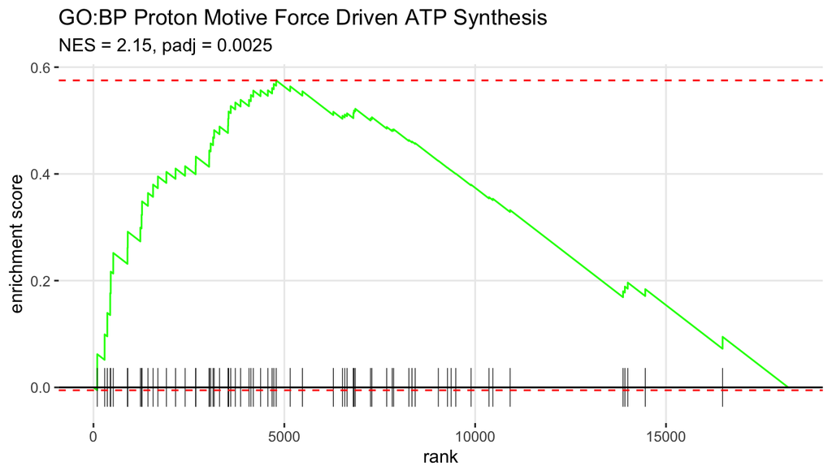

The convergent enrichment of multiple interconnected mitochondrial pathways—respiratory chain complex assembly (which builds the electron transport chain), NADH dehydrogenase complex assembly (Complex I assembly specifically), proton motive force-driven ATP synthesis (ATP synthase function), and oxidative phosphorylation (the overall process)—suggests a coherent biological program. Specifically, these findings indicate that ApoE2 expression enhances mitochondrial bioenergetic capacity compared to ApoE4 expression in hepatocytes.

The inclusion of “translation at synapse” among enriched pathways was unexpected in a liver tissue analysis, as this term typically applies to neuronal tissues. This likely represents either: (1) annotation artifacts where genes involved in general translational machinery are also annotated to synapse-specific processes, or (2) genuine enrichment of ribosomal/translational components that support increased protein synthesis for mitochondrial biogenesis

## 9.2 Brain

### 9.2.1 Over-Representation Analysis (ORA)

This heterogeneous enrichment pattern suggests that the transcriptional response to ApoE4→ApoE2 conversion in brain affects multiple distinct biological systems rather than a single coherent pathway. The prominence of neuroendocrine-related terms (neurohypophyseal hormone activity, vasopressin receptor binding, maternal aggressive behavior) is particularly notable and may reflect effects on hypothalamic-pituitary signaling. The enrichment of basic metabolic pathways (glycolysis, amino acid biosynthesis) alongside behavioral and neuroendocrine terms suggests broad metabolic and functional remodeling in response to ApoE isoform switching.

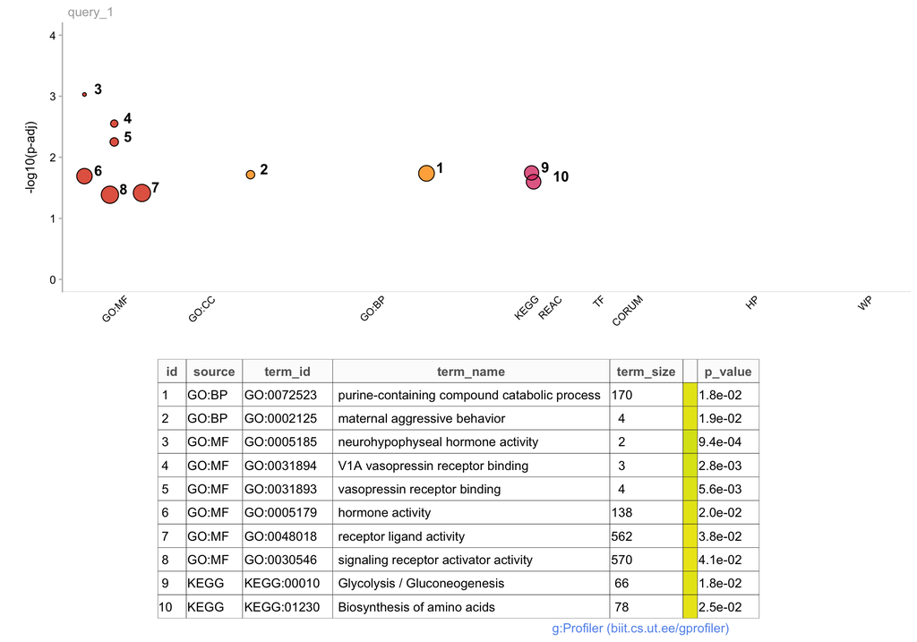

### 9.2.2 Gene Set Enrichment Analysis (GSEA)

| pathway | NES | padj | size |
| --- | --- | --- | --- |
| GOBP_REGULATION_OF_CHROMATIN_ORGANIZATION | 2.239 | 0.019 | 35 |
| GOBP_EPOXYGENASE_P450_PATHWAY | 2.228 | 0.019 | 26 |
| GOBP_ARACHIDONIC_ACID_METABOLIC_PROCESS | 2.188 | 0.009 | 59 |
| GOBP_XENOBIOTIC_METABOLIC_PROCESS | 2.137 | 0.005 | 98 |
| GOBP_SPLICEOSOMAL_COMPLEX_ASSEMBLY | 2.136 | 0.020 | 49 |
| GOBP_URONIC_ACID_METABOLIC_PROCESS | 2.128 | 0.031 | 15 |
| GOBP_DENDRITE_MORPHOGENESIS | 1.891 | 0.009 | 188 |
| GOBP_POSITIVE_REGULATION_OF_MRNA_CATABOLIC_PROCESS | 1.885 | 0.027 | 91 |
| GOBP_CELLULAR_RESPONSE_TO_XENOBIOTIC_STIMULUS | 1.864 | 0.019 | 153 |
| GOBP_ACTION_POTENTIAL | 1.837 | 0.018 | 160 |
| GOBP_POSITIVE_REGULATION_OF_MRNA_METABOLIC_PROCESS | 1.828 | 0.019 | 125 |
| GOBP_REGULATION_OF_MRNA_PROCESSING | 1.818 | 0.019 | 129 |
| GOBP_REGULATION_OF_MRNA_METABOLIC_PROCESS | 1.792 | 0.005 | 274 |
| GOBP_NEGATIVE_REGULATION_OF_GENE_EXPRESSION_EPIGENETIC | 1.768 | 0.027 | 145 |
| GOBP_NEURON_PROJECTION_ORGANIZATION | 1.734 | 0.031 | 116 |
| GOBP_DENDRITE_DEVELOPMENT | 1.688 | 0.006 | 315 |
| GOBP_SYNAPSE_ASSEMBLY | 1.583 | 0.023 | 267 |
| GOBP_POSTSYNAPSE_ORGANIZATION | 1.558 | 0.031 | 283 |
| GOBP_CHROMATIN_REMODELING | 1.538 | 0.006 | 472 |
| GOBP_MRNA_PROCESSING | 1.467 | 0.019 | 453 |
| GOBP_REGULATION_OF_SYNAPSE_STRUCTURE_OR_ACTIVITY | 1.418 | 0.041 | 365 |

All pathways exhibited positive enrichment scores, indicating coordinated upregulation of genes in these functional categories following ApoE4→ApoE2 conversion. The enrichment pattern in brain contrasts markedly with liver, where mitochondrial oxidative metabolism dominated. Instead, brain tissue shows coordinated changes in three major functional domains: (1) chromatin organization and epigenetic regulation, suggesting remodeling of gene expression programs; (2) cytochrome P450-mediated metabolism of arachidonic acid and xenobiotics, implicating changes in lipid mediator synthesis and detoxification capacity; and (3) neuronal structural plasticity and synaptic organization, indicating potential effects on neural circuit architecture.

#### 9.2.2.1 Reducing Redundant Pathways with `collapsePathways`

Given the extensive overlap in leading-edge genes between pathways, we applied the `collapsePathways` function from the `fgsea` package to reduce redundancy and identify independent biological themes. This analysis groups pathways with highly similar gene membership, retaining only the most significantly enriched representative from each cluster.

```
Original significant pathways: 21
```

```
After collapsing: 11
```

| pathway | NES | padj | size |
| --- | --- | --- | --- |
| GOBP_REGULATION_OF_CHROMATIN_ORGANIZATION | 2.239 | 0.019 | 35 |
| GOBP_XENOBIOTIC_METABOLIC_PROCESS | 2.137 | 0.005 | 98 |
| GOBP_SPLICEOSOMAL_COMPLEX_ASSEMBLY | 2.136 | 0.020 | 49 |
| GOBP_URONIC_ACID_METABOLIC_PROCESS | 2.128 | 0.031 | 15 |
| GOBP_ACTION_POTENTIAL | 1.837 | 0.018 | 160 |
| GOBP_REGULATION_OF_MRNA_METABOLIC_PROCESS | 1.792 | 0.005 | 274 |
| GOBP_DENDRITE_DEVELOPMENT | 1.688 | 0.006 | 315 |
| GOBP_SYNAPSE_ASSEMBLY | 1.583 | 0.023 | 267 |
| GOBP_CHROMATIN_REMODELING | 1.538 | 0.006 | 472 |
| GOBP_MRNA_PROCESSING | 1.467 | 0.019 | 453 |
| GOBP_REGULATION_OF_SYNAPSE_STRUCTURE_OR_ACTIVITY | 1.418 | 0.041 | 365 |

**Collapsed pathways** (redundant with retained representatives): - Multiple chromatin-related terms collapsed into “regulation of chromatin organization” and “chromatin remodeling” - Several mRNA metabolism terms collapsed into “regulation of mRNA metabolic process” and “mRNA processing” - Various dendritic and synaptic terms collapsed into “dendrite development,” “synapse assembly,” and “regulation of synapse structure or activity” - Xenobiotic-related pathways (epoxygenase P450, arachidonic acid metabolism, cellular response to xenobiotic stimulus) collapsed into “xenobiotic metabolic process”

The retention of both “chromatin organization” and “chromatin remodeling” as independent pathways despite their conceptual similarity suggests these represent distinct aspects of epigenetic regulation (organizational state versus active remodeling machinery). Similarly, the preservation of multiple synaptic/dendritic pathways indicates genuine enrichment across different aspects of neuronal structural plasticity rather than redundant detection of the same underlying biology.

This pathway reduction analysis strengthens confidence in the original findings by demonstrating that the breadth of enriched pathways reflects genuine biological diversity in the brain’s response rather than statistical artifacts arising from pathway overlap in gene set databases.